# Assignment 2 - Electricity Market Prices

### Irmak Dai

In this report electricity market prices (MCP & SMP) of July 2020 are analyzed using dplyr and ggplot2.

#### Background:

SMP: System marginal price  
MCP: Market clearing price  
MCPs are settled in a single session and they do not change.  
SMP is always higher than MCP if system has Energy Deficit, and lower if there is Energy Surplus.  
Positive imbalance price (TL/MWH) = 0.97xmin(PTF,SMF)  
Negative imbalance price (TL/MWH) = 1.03xmax(PTF,SMF)

Loading required packages and setting working directory:

```r
#loading required packages
library(tidyverse)
library(lubridate)
#setting working directory
setwd("C:/Users/Asus/Desktop/Summer 2020/IE 48A/IE48a - R")
```

Reading and exploring the data:

```r
data <- read.csv("ptf-smf.csv")
data %>% glimpse()
```

```
## Rows: 744
## Columns: 6
## $ Tarih                               <chr> "01.07.20 00:00", "01.07.20 01:...
## $ PTF                                 <chr> "323,85", "326,95", "324,31", "...
## $ SMF                                 <chr> "211,00", "201,00", "211,00", "...
## $ Pozitif.Dengesizlik.Fiyatı..TL.MWh. <chr> "204,67", "194,97", "204,67", "...
## $ Negatif.Dengesizlik.Fiyatı..TL.MWh. <chr> "333,57", "336,76", "334,04", "...
## $ SMF.Yön                             <chr> "?Enerji Fazlası", "?Enerji Faz...
```

I noticed that comma was used as decimal seperator, I replaced all commas with points in necessary columns.

```r
data$SMF <- gsub(",",".",data$SMF)
data$PTF <- gsub(",",".",data$PTF)
data$Pozitif.Dengesizlik.Fiyatı..TL.MWh. <- gsub(",",".",data$Pozitif.Dengesizlik.Fiyatı..TL.MWh.)
data$Negatif.Dengesizlik.Fiyatı..TL.MWh. <- gsub(",",".",data$Negatif.Dengesizlik.Fiyatı..TL.MWh.)

data$SMF <- as.numeric(data$SMF)
data$PTF <- as.numeric(data$PTF)
data$Pozitif.Dengesizlik.Fiyatı..TL.MWh. <- as.numeric(data$Pozitif.Dengesizlik.Fiyatı..TL.MWh.)
data$Negatif.Dengesizlik.Fiyatı..TL.MWh. <- as.numeric(data$Negatif.Dengesizlik.Fiyatı..TL.MWh.)
```

Since the column names are in Turkish, I translated them to English. Also I added seperate columns for date and time components.

```r
data_english <- data %>%
  rename(MCP=PTF, SMP=SMF, dt=Tarih, "positive_imbalance_price(TL/MWh)"=Pozitif.Dengesizlik.Fiyatı..TL.MWh.,"negative_imbalance_price(TL/MWh)"=Negatif.Dengesizlik.Fiyatı..TL.MWh.)%>%
  mutate(SMP_direction=case_when(SMF.Yön=="?Enerji Fazlası" ~ "Energy Surplus", SMF.Yön=="? Enerji Açığı"~ "Energy Deficit", SMF.Yön=="? Dengede" ~ "In Balance")) %>%
  mutate(dt=as.POSIXct(dt, format="%d.%m.%y %H:%M"), MCP_SMP_diff=MCP-SMP)%>%
  mutate(day=lubridate::day(dt),month=lubridate::month(dt),year=lubridate::year(dt),hour=lubridate::hour(dt),day_of_week=lubridate::wday(dt)) %>%
  select(dt,day,hour,day_of_week, MCP, SMP, "positive_imbalance_price(TL/MWh)","negative_imbalance_price(TL/MWh)",MCP_SMP_diff, SMP_direction)
```

I plotted hourly SMP and MCP to have a general idea of the data

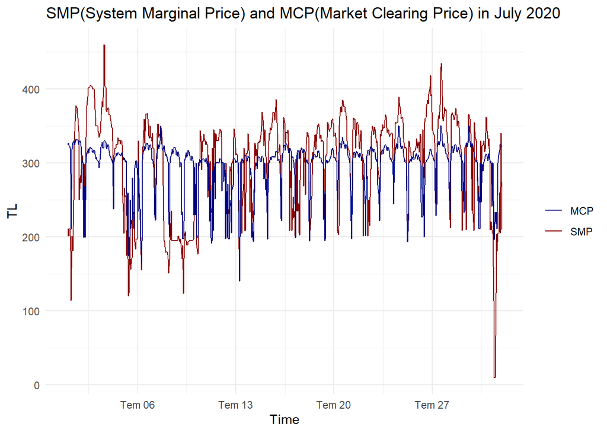

```r
ggplot(data_english, aes(x=dt))+geom_line(aes(y=SMP,color="SMP"))+geom_line(aes(y=MCP,color="MCP"))+labs(x="Time", y="TL",title="SMP(System Marginal Price) and MCP(Market Clearing Price) in July 2020")+scale_color_manual(name = "", values = c("SMP"="darkred", "MCP"="navy"))+theme_minimal()
```

The data has many ups and downs, it is hard to examine this way. A reasonable way may be to analyze daily averages.

Line chart of daily averages of SMP and MCP

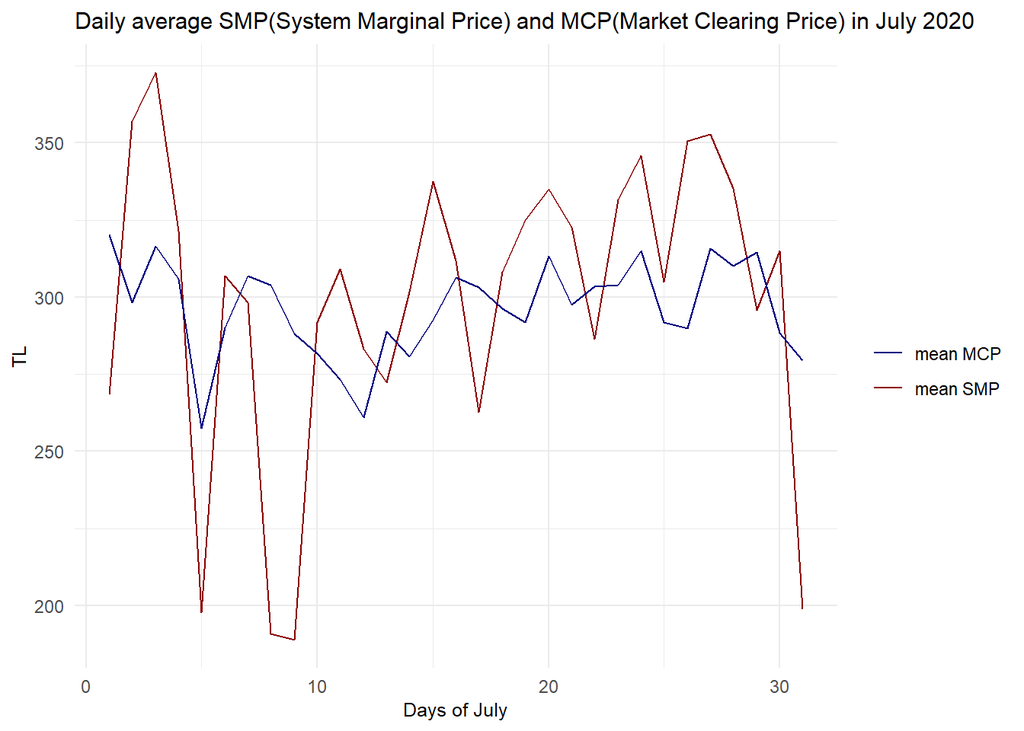

```r
average_by_day <- data_english %>%
  select(day, day_of_week,MCP,SMP,`positive_imbalance_price(TL/MWh)`,`negative_imbalance_price(TL/MWh)`) %>%
  group_by(day) %>%
  summarise(day_of_week, mean_SMP=mean(SMP), mean_MCP=mean(MCP), mean_PIP=mean(`positive_imbalance_price(TL/MWh)`), mean_NIP=mean(`negative_imbalance_price(TL/MWh)`)) %>%
  mutate(day_of_week=case_when(day_of_week==1~"Sunday", day_of_week==2~"Monday", day_of_week==3~"Tuesday", day_of_week==4~"Wednesday", day_of_week==5~"Thursday", day_of_week==6~"Friday", day_of_week==7~"Saturday"))

ggplot(average_by_day, aes(x=day,y=""))+geom_line(aes(y=mean_SMP,color="mean SMP"))+geom_line(aes(y=mean_MCP,color="mean MCP"))+labs(x="Days of July", y="TL",title="Daily average SMP(System Marginal Price) and MCP(Market Clearing Price) in July 2020")+scale_color_manual(name="",values = c("mean SMP"="darkred","mean MCP"="navy"))+theme_minimal()+theme(title=element_text(size=9.5))
```

I thought that we can also analyze average SMP and MCP values by days of week

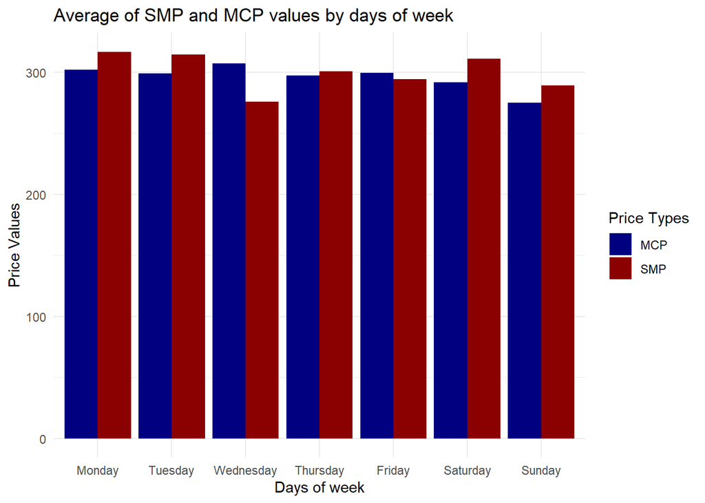

```r
average_by_day$day_of_week <- factor(average_by_day$day_of_week, levels= c("Monday", "Tuesday", "Wednesday", "Thursday", "Friday", "Saturday", "Sunday"))

average_by_day_of_week <- average_by_day %>%
  group_by(day_of_week) %>%
  summarise(mean_SMP_dow=mean(mean_SMP), mean_MCP_dow=mean(mean_MCP)) %>%
  arrange(day_of_week)

average_by_day_of_week_arranged <- average_by_day_of_week %>%
  pivot_longer(cols=c(mean_SMP_dow,mean_MCP_dow), names_to="price_types", values_to="price_values")

ggplot(average_by_day_of_week_arranged,aes(x=day_of_week,y=price_values,fill=price_types))+geom_bar(stat="Identity",position = "dodge")+scale_fill_manual(values=c("navy", "darkred"),name = "Price Types", labels = c("MCP", "SMP"))+theme_minimal()+labs(x="Days of week", y="Price Values",title="Average of SMP and MCP values by days of week")
```

I plotted a pie chart to see the breakdown of energy surplus, deficit and balance

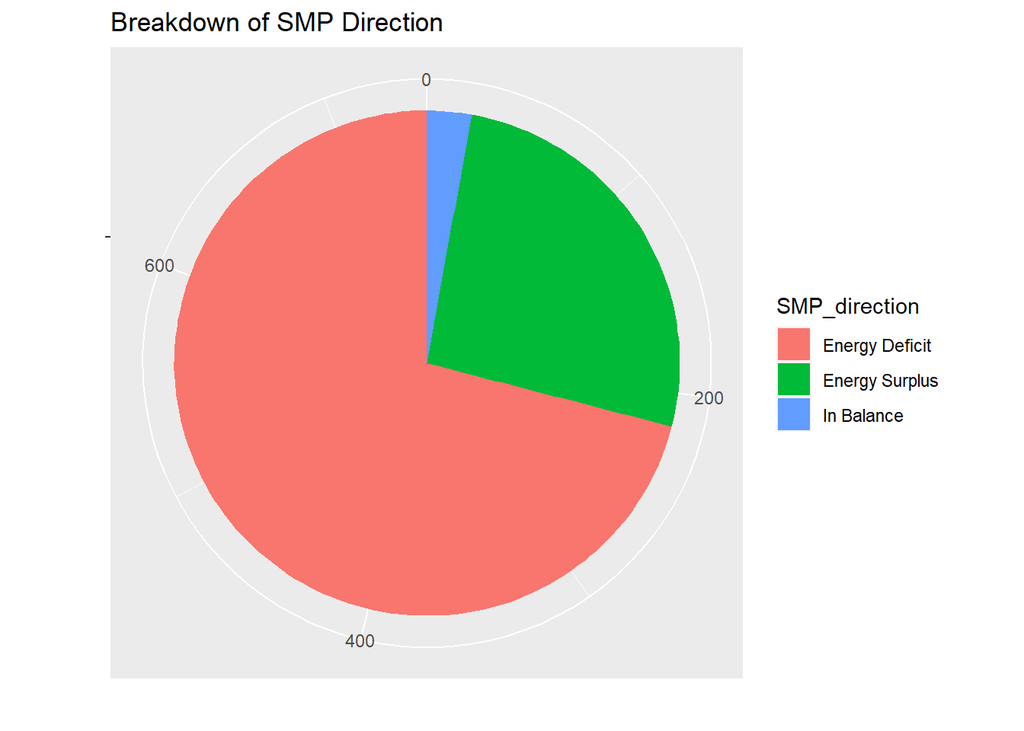

```r
summary_SMP_direction <- data_english %>%
  group_by(SMP_direction) %>%
  summarise(count=n())
ggplot(summary_SMP_direction, aes(x="",y=count,fill=SMP_direction))+geom_bar(stat="identity",width=1)+coord_polar("y")+labs(x="",y="",title="Breakdown of SMP Direction")
```

I realized that I have only worked with SMP and MCP data. So I plotted daily averages of positive & negative imbalance prices in order to see what can be done.

[figure not shown]

```r
ggplot(average_by_day,aes(x=day))+geom_line(aes(y=mean_PIP,color="red"))+geom_line(aes(y=mean_NIP, color="blue"))+labs(x="Days of July", y="TL/MWh",title="Daily average of imbalance prices in July 2020")+scale_color_discrete(name = "", labels = c("Daily average positive imbalance price", "Daily average negative imbalance price"))+theme_minimal()
```

Both lines have similar ups and downs. Since imbalance prices depends on SMP and and MCP, I decided the plot a point graph of MCP and SMP. Above the purple line there is energy surplus & below energy deficit

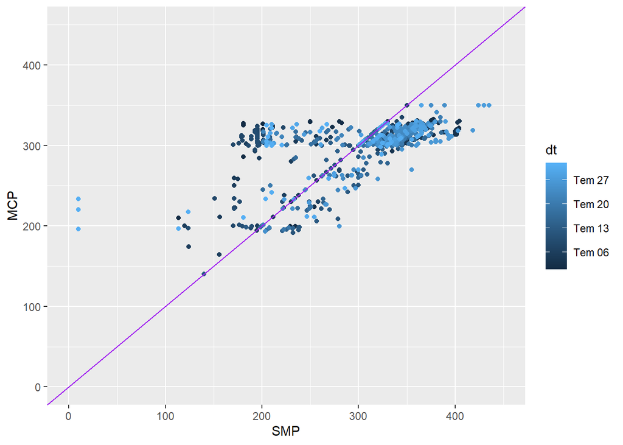

```r
ggplot(data_english)+geom_point(aes(x=SMP,y=MCP,color=dt))+geom_abline(slope=1,intercept=0,color="purple")+xlim(0,450)+ylim(0,450)
```

Finally I wanted to see how SMP and MCP change throughout a day, so I took average for hours of day. It can be clearly seen that both SMP and MCP have a minimum value in the mornings (~6am).

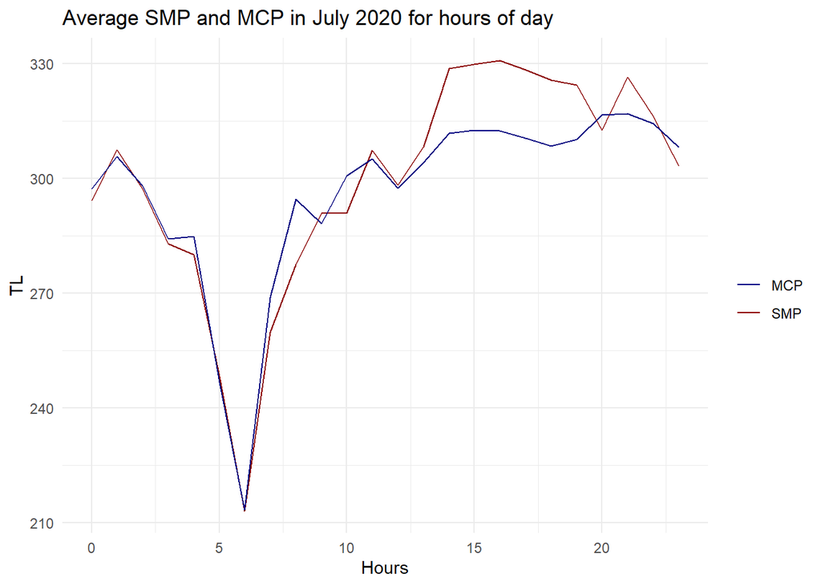

```r
average_by_hours <- data_english %>%
  group_by(hour) %>%
  summarise(mean_SMP=mean(SMP), mean_MCP=mean(MCP))

ggplot(average_by_hours, aes(x=hour))+geom_line(aes(y=mean_SMP,color="SMP"))+geom_line(aes(y=mean_MCP, color="MCP"))+labs(x="Hours", y="TL",title="Average SMP and MCP in July 2020 for hours of day")+scale_color_manual(name = "", values = c("SMP"="darkred", "MCP"="navy"))+theme_minimal()
```

## References

https://rapor.epias.com.tr/rapor/xhtml/ptfSmfListeleme.xhtml